# WSF_M2_woAD slides

## M2 - Water Scarcity Footprint in LCA

#### 1. Evolution of WSF

#### 2. Early development (ratio scale)

#### 3. AWARE (AMD)

###### 3.1 native scale

###### 3.2 aggregated CFs

### 1. Evolution of WSF in LCA

Consensus-based method development to assess water use in LCA: https://wulca-waterlca.org/aware/

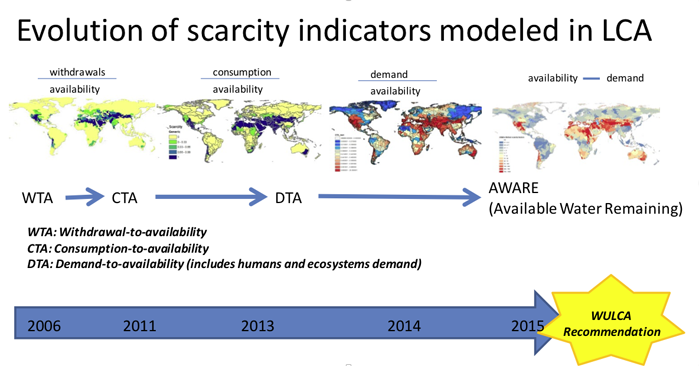

### 2. Ratio scale

##### 2006 - WTA (Withdrawal-to-availability)

- water **withdrawn** in a region (watershed-level) **/** water available in the region

##### 2011 - CTA (Consumption-to-availability)

- water **consumed by humans** in a region **/** water available in the region

**WATER USE: withdrawal vs. consumption**

- withdrawal: “water diverted/withdrawn from a surface water or groundwater source.”
- consumption: “water use that permanently withdraws water from its source; water that is no longer available because it has evaporated, been transpired by plants, incorporated into products or crops, consumed by people or livestock, or otherwise removed from the immediate water environment.” Cohen (2002)10.5070/G311610464

### 2. Ratio scale (cont'd)

##### 2013 - DTA (Demand-to-availability)

- water **demand for both human and ecosystem needs** in a region **/** water available in the region

##### Problems of ratio scale

- WTA/CTA/DTA = 0.5 means 50% of water in the region is withdrawn/consumed/needed for sustaining human/ecosystem
- Do not know exact volumn of water available / remaining in the region (10^x m3?)
- leading to strange results: WSF(Sahara) **<<<** WSF(Belgium)

##### Solution:

Using differences instead of ratio: [availabiltiy - demand]

### 3. 2015 - AWARE (Available Water Remaining)

**Available water remaining = Availabiltiy - Demand (AMD)**

**Availability** "Total river discharge, sum of surface runoff and groundwater recharge"

**Demand** "water consumed by domestic, industrial, agricultural and livestock uses... plus Freshwater Ecosystems Demand."

##### Underlying Assumption: the more water remaining per area, the lower the potential to deprive another user

### 3. 2015 - AWARE (Available Water Remaining)

#### AWARE recommended for:

PEF Recommendations (EU)

International EPD system

FAO LEAP Guidelines

WWF Water Risk Filter

Aims to answer:

##### "the potential of depriving another user of water (human or ecosystems) when consuming water in this area"

*Boulay A-M et al. 2015.10.1007/s11367-015-0869-8*

### 3.1. AWARE (cont'd)

AMD[worldave] = 0.0136 m3/m2/month (~10 big bottle of coke)

CF: based on 1/AMD, the inverse of the difference between availability and demand:

#### CF: Fn(1/AMD)

**CF[i] = AMD[worldave] / AMD[i] = 0.0136 [m3/m2/month] / AMD[i]**

**AMD[i] = (Availability[m3] - Human Cnsmpt[m3] - Ecosystem needs[m3]) /m2/month**

### 3.1. AWARE (cont'd)

##### - AWARE100 (native scale: monthly/watershed-level)

CF[i] = CF[max] = 100 if Demand ≥ Availability

CF[i] = AMD[worldave] / AMD[i]

##### Consensus-based approach:

CF[max] = 100

CF[min] = 0.1

AMD[i] = 0.136 m3/m2/month (minimum deprivation potential, 10 times more AMD than world average)

### 3.1 AWARE (cont'd)

Consensus-based approach:

AWARE100: Represents the Available Water Remaining per unit of surface in a given watershed relative to the world average, after human and aquatic ecosystem demands have been met.

- AWARE100 or AWARE is limited to a range from **0.1 to 100**
- AWARE10 is limited to a range from **0.1 to 10**
- AWARE1000 is limited to a range from **0.1 to 1000**
- AWARE100_EWR+50%, uses a higher value for the Environmental Water Requirement (Ecosystem demand), by taking 150% of the original value

### 3.2 AWARE - Aggregated CFs

LCI often do not have the detailed level of data (as in AWARE native scale)

**Aggregation needed** from monthly/watershed to annual/country-level CF

https://wulca-waterlca.org/aware/faq/

Why are there different factors? What is the difference between “agri” and “non-agri”? Is irrigation water consumption included in both?

At the native scale, monthly and (sub)basin scale, there is only one AWARE factor, ... When this factor has to be provided at different scales, such as annual or country scale, the factors must be aggregated. The difference between “agri” and “non-agri” only lies in the way they are aggregated, reflecting better the temporal or geographical patterns of consumption for agricultural or non agricultural activities, ... The calculation of the native CF is always the same, and always includes all human water consumption.

### 3.2 AWARE - Aggregated CFs

##### Agri vs. non-agri CF

##### World-average CF: DO NOT use world-average CF for decision making

CF=43 for generic

CF=20 for non-agri

CF=46 for agri

##### Interpreting the aggregated CF

represent where/when water is most consumed/needed: dryer months/regions

DO NOT represent the average situation of the country/year:

- during aggregation, CF may exclude large regions where no/low water consumption occur (e.g., deserts regions; most of Australia; most of Canada)

strongly affected by agri CF (i.e. generic CFs closer to agri CFs)

### End of Module 2

#### Take home message:

LCA-based WSF: ratio scale --> AWARE (AMD)

AWARE - native scale vs. aggregated CFs

**References**

Cohen, Russell A. (2002). Handbook of Water Use and Conservation. https://escholarship.org/content/qt85788843/qt85788843.pdf?t=q9nsf5

Boulay, A.-M., Bare, J., De Camillis, C., Döll, P., Gassert, F., Gerten, D., … Pfister, S. (2015). Consensus building on the development of a stress-based indicator for LCA-based impact assessment of water consumption: outcome of the expert workshops. The International Journal of Life Cycle Assessment, 20(5), 577–583. doi:10.1007/s11367-015-0869-8